신록예찬's 블로그

# (노트) matplotlib으로 산점도, 라인플랏

Sep 9, 2021 • 신록예찬 • 7 min read

시각화

- 몸무게와 키
- 상관계수 (몸무게-키 예제의 심층분석을 위한 핵심 통계개념)
- line plot
- plt.plot()
- 여러그림그리기
  - 겹쳐그리기
  - 수평선 수직선
  - 따로그리기 (subplot)
  - 예제: Anscombe's quartet
  - Appendex: 표본XX vs 모XX

```python
import matplotlib.pyplot as plt
```

`-` $(x,y)$를 점으로 찍은것..

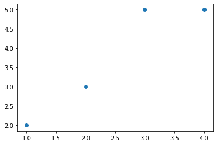

```python
x=[1,2,3,4]
y=[2,3,5,5]
plt.plot(x,y,'o') ## 'o'
```

`-` 산점도는 보통 $X$와 $Y$의 관계를 알고 싶을 경우 그린다.

- 박스클랏과 히스토그램을 위해서는 하나의 변수만 필요, 산점도를 위해서는 두개의 변수가 필요함.
- 두변수 $\to$ 두변수의 관계!

### 몸무게와 키

`-` 아래와 같은 자료를 수집하였다고 하자.

- 몸무게 = [44,48,49,58,62,68,69,70,76,79]
- 키 = [159,160,162,165,167,162,165,175,165,172]

```python
x=[44,48,49,58,62,68,69,70,76,79] # 몸무게
y=[159,160,162,165,167,162,165,175,165,172] # 키
```

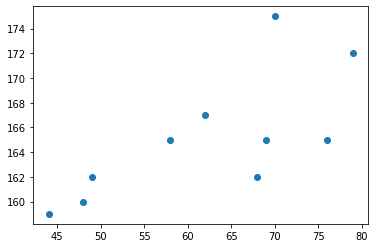

```python
plt.plot(x,y,'o')
```

- 키가 큰 사람일수록 몸무게도 많이 나감 (**반대도 성립**)
- 키와 몸무게는 관계가 있어보인다. (정비례) // 네이버검색 "정비례반비례" 지식백과탭 3번째.

`-` 얼만큼 정비례인지?

- 이 질문에 대답하려면 상관계수를 알아야한다.
- 상관계수에 대한 개념도는 산점도를 이해함에 있어서 핵심개념이다.

### 상관계수 (몸무게-키 예제의 심층분석을 위한 핵심 통계개념)

`-` (표본)상관계수

$$r=\frac{\sum_{i=1}^{n}(x_i-\bar{x})(y_i-\bar{y})}{\sqrt{\sum_{i=1}^{n}(x_i-\bar{x})^2 \sum_{i=1}^{n}(y_i-\bar{y})^2 }}$$

- 복잡해보이지만 하여튼 (1) 분자계산하고 (2) 분모계산해서 분자를 분모로 나누면 되는 것
- 분모는 계산했다고 치자. 그걸 어떠한 상수 $c$로 생각하고 분자안에 넣을수도 있다.

$$r=\sum_{i=1}^{n}\frac{1}{c}(x_i-\bar{x})(y_i-\bar{y})$$

- 위의 식은 아래와 같이 쓸 수 있다.

$$r=\sum_{i=1}^{n}\left(\frac{x_i-\bar{x}}{\sqrt{\sum_{i=1}^{n}(x_i-\bar{x})^2}}\frac{y_i-\bar{y}}{\sqrt{\sum_{i=1}^{n}(y_i-\bar{y})^2}}\right)$$

- 편의상 아래와 같이 정의하자. $z_x=\frac{x_i-\bar{x}}{\sqrt{\sum_{i=1}^n(x_i-\bar{x})^2}}, z_y=\frac{y_i-\bar{y}}{\sqrt{\sum_{i=1}^n(y_i-\bar{y})^2}}$ 라고 정의하자.
- 결국 아래와 같은 모양이다.

$$r=\sum_{i=1}^{n}z_x z_y$$

`-` 의미?

```python
x= np.array(x)
y= np.array(y)
```

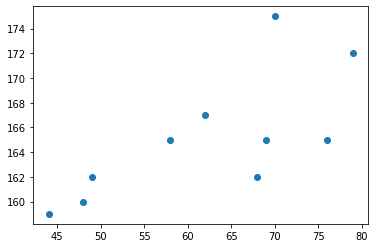

```python
plt.plot(x,y,'o')
```

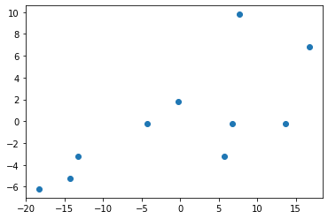

```python
plt.plot(x-np.mean(x),y-np.mean(y),'o')
```

`-` $a=\sqrt{\sum_{i=1}^n (x_i-\bar{x})^2}, b=\sqrt{\sum_{i=1}^n (y_i-\bar{y})^2}$

```python
a=np.sqrt(sum((x-np.mean(x))**2))
b=np.sqrt(sum((y-np.mean(y))**2))
```

```python
a,b
```

```
(36.58004920718396, 15.218409903797438)
```

- 아무튼 $a>b$ 이므로 $\{x_i\}$들이 $\{y_i\}$보다 좀 더 퍼져있다. (=평균근처에 몰려있지 않다)

`-` 사실 $a=\sqrt{n}\times {\tt np.std(x)}$, $b=\sqrt{n}\times {\tt np.std(y)}$ 해도된다.

```python
n=len(x)
np.sqrt(n)*np.std(x),np.sqrt(n)*np.std(y)
```

```
(36.58004920718397, 15.21840990379744)
```

- 즉 np.std(x)는 $\sqrt{\frac{1}{n}\sum_{i=1}^{n}(x_i-\bar{x})^2}$를 계산해준다.
- 참고로 np.std(x,ddof=1)을 하면 $\sqrt{\frac{1}{n-1}\sum_{i=1}^{n}(x_i-\bar{x})^2}$ 이 계산된다.

`-` $(z_x,z_y)$를 그려보자!

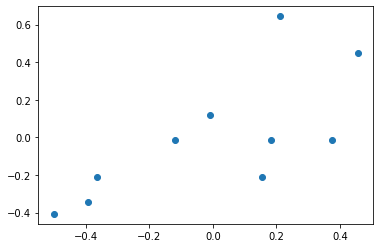

```python
zx=(x-np.mean(x))/a
zy=(y-np.mean(y))/b
plt.plot(zx,zy,'o')
```

- 평균도 비슷하고 퍼진정도도 비슷하다.

`-` 질문1: $r$ 의 값이 양수인가? 음수인가?

plotly 사용하여 그려보자.

```python
import plotly.express as px
from IPython.display import HTML
fig=px.scatter(x=zx,y=zy)
HTML(fig.to_html(include_plotlyjs='cdn', include_mathjax=False))
```

[interactive chart not shown]

- $z_x$와 $z_y$의 곱한값이 양수인것과 음수인것을 체크해보자.
- 양수인쪽이 많은가, 음수인쪽이 많은가?
- $z_x$와 $z_y$의 곱한값을 모두 더하면 양수가 될까 음수가 될까?

`-` 질문2: 아래와 같은 두개의 데이터set이 있다고 하자.

```python
x1=np.arange(0,10,0.1)
y1=x1+np.random.normal(loc=0,scale=7,size=len(x1))
```

```python
x2=np.arange(0,10,0.1)
y2=x2+np.random.normal(loc=0,scale=1,size=len(x2))
```

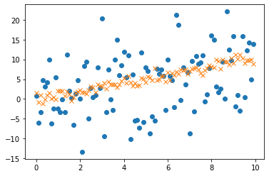

```python
plt.plot(x1,y1,'o')
plt.plot(x2,y2,'x')
```

각 데이터셋의 표준상관계수를 각각 $r_1$, $r_2$라고 하자.

(1) $r_1$, $r_2$는 양수인가 음수인가?

(2) $r_1$, $r_2$의 값 중 어떠한 값이 더 절대값이 큰가?

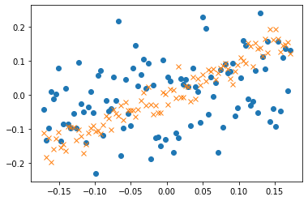

```python
n=len(x1)
xx1= (x1-np.mean(x1)) / (np.std(x1)*np.sqrt(n))
yy1= (y1-np.mean(y1)) / (np.std(y1)*np.sqrt(n))
xx2= (x2-np.mean(x2)) / (np.std(x2)*np.sqrt(n))
yy2= (y2-np.mean(y2)) / (np.std(y2)*np.sqrt(n))
plt.plot(xx1,yy1,'o') # 파란색
plt.plot(xx2,yy2,'x') # 주황색
```

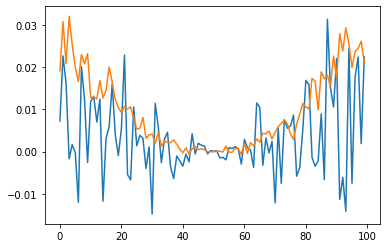

```python
plt.plot(xx1*yy1) # 파란색
plt.plot(xx2*yy2) # 주황색
```

```python
sum(xx1*yy1), sum(xx2*yy2)
```

```
(0.33942926710894855, 0.9637575949669123)
```

```python
np.corrcoef(xx1,yy1), np.corrcoef(xx2,yy2)
```

```
(array([[1.        , 0.33942927],
        [0.33942927, 1.        ]]),
 array([[1.        , 0.96375759],
        [0.96375759, 1.        ]]))
```

### line plot

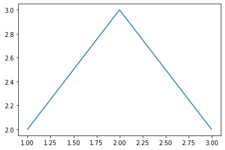

```python
x=[1,2,3]
y=[2,3,2]
plt.plot(x,y)
```

### plt.plot()

```python
x=[1,2,3]
y=[2,3,2]
```

`-` 다양한 마커를 이용하여 그림을 그려보자.

```python
_x=[1,2,3]
_y=[2,3,2]
```

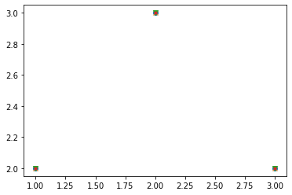

```python
plt.plot(_x,_y,'o')
plt.plot(_x,_y,'x')
plt.plot(_x,_y,'v')
plt.plot(_x,_y,'.')
```

### 여러그림그리기

#### 겹쳐그리기

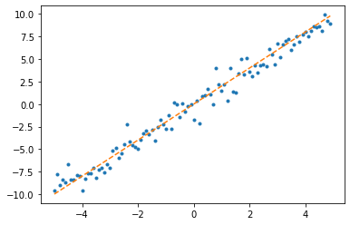

```python
x=np.arange(-5,5,0.1)
y=2*x+np.random.normal(loc=0,scale=1,size=100)
plt.plot(x,y,'.')
plt.plot(x,2*x,'--')
```

#### 수평선 수직선

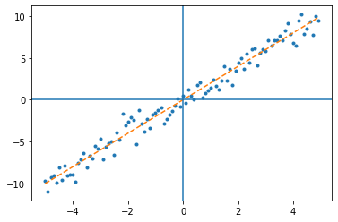

```python
x=np.arange(-5,5,0.1)
y=2*x+np.random.normal(loc=0,scale=1,size=100)
plt.plot(x,y,'.')
plt.plot(x,2*x,'--')
plt.axhline(y=0)
plt.axvline(x=0)
```

#### 따로그리기 (subplot)

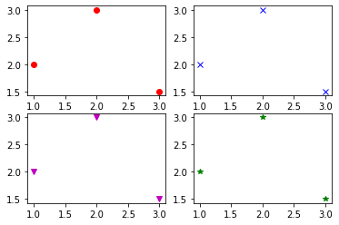

```python
x=[1,2,3]
y=[2,3,1.5]
_, axs = plt.subplots(2,2)
axs[0,0].plot(x,y,'or')
axs[0,1].plot(x,y,'xb')
axs[1,0].plot(x,y,'vm')
axs[1,1].plot(x,y,'*g')
```

```python
plt.subplots??
```

[output not shown]

[output cut: 100 more lines]

[output not shown]

- plt.subplots 는 (fig,axs)를 튜플로 리턴.
- 우리는 뒤의 axs만 관심있으므로 앞의 fig는 underscore 처리

#### 예제: Anscombe's quartet

`-` 교훈1: 데이터를 분석하기 전에 항상 시각화를 하자.

`-` 잠깐 상관계수에 대한 성질 요약

- 상관계수는 -1~1 사이의 값을 가진다.
- 완전한 직선이라면 상관계수가 1 또는 -1 이다.
- 상관계수가 1에 가까우면 양의상관관계에 있다고 말하고 -1에 가까우면 음의 상관관계에 있다고 말한다.

`-` 의문: 자료의 모양이 직선모양에 가까우면 상관계수가 큰것이 맞나?

- 하나의 값을 엄청 크게 만들면 상관계수를 키울수 있지 않나?

`-` 상관계수는 좋은 것 맞나? (=상관계수는 두 변수의 관계를 설명하기에 충분히 적절한 통계량인가?)

```python
x = [10, 8, 13, 9, 11, 14, 6, 4, 12, 7, 5]
y1 = [8.04, 6.95, 7.58, 8.81, 8.33, 9.96, 7.24, 4.26, 10.84, 4.82, 5.68]
y2 = [9.14, 8.14, 8.74, 8.77, 9.26, 8.10, 6.13, 3.10, 9.13, 7.26, 4.74]
y3 = [7.46, 6.77, 12.74, 7.11, 7.81, 8.84, 6.08, 5.39, 8.15, 6.42, 5.73]
x4 = [8, 8, 8, 8, 8, 8, 8, 19, 8, 8, 8]
y4 = [6.58, 5.76, 7.71, 8.84, 8.47, 7.04, 5.25, 12.50, 5.56, 7.91, 6.89]
```

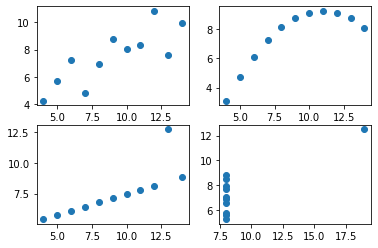

```python
_, axs = plt.subplots(2,2)
axs[0,0].plot(x,y1,'o')
axs[0,1].plot(x,y2,'o')
axs[1,0].plot(x,y3,'o')
axs[1,1].plot(x4,y4,'o')
```

`-` 상관계수비교

```python
## 상관계수 구하는 방법1
n=len(x)
xtilde =(x-np.mean(x))/ (np.std(x)*np.sqrt(n))
y1tilde =(y1-np.mean(y1))/ (np.std(y1)*np.sqrt(n))
print(sum(xtilde*y1tilde))
## 상관계수 구하는 방법2
print(np.corrcoef(x,y1))
```

```
0.81642051634484
[[1.         0.81642052]
 [0.81642052 1.        ]]
```

```python
print(np.corrcoef([x,y1,y2,y3]))
print(np.corrcoef([x4,y4]))
```

```
[[1.         0.81642052 0.81623651 0.81628674]
 [0.81642052 1.         0.7500054  0.46871668]
 [0.81623651 0.7500054  1.         0.58791933]
 [0.81628674 0.46871668 0.58791933 1.        ]]
[[1.         0.81652144]
 [0.81652144 1.        ]]
```

`-` 비교결과 4개의 플랏에 대한 상관계수는 모두 0.816 으로 같다.

`-` 상관계수는 두 변수의 관계를 설명하기에 부적절하다.

- 상관계수는 두 변수가 1번그림과 같은 선형관계에 있을때 그 정도를 나타내는 통계량일 뿐이다.
- 선형관계가 아닌것처럼 보이는 자료에서는 (계산할 수는 있으나) 의미가 없다.

`-` 교훈2: 기본적인 통계량들은 실제자료를 분석하기에 부적절할 수 있다. (= 기본적인 통계량은 적절한 가정이 동반되어야 의미가 있다)

**Note:** 통계학자는 (1) 이런 적절한 가정을 수학적인 언어로 정의하고 (2) 그 가정하에서 제안한 통계량이 의미있음을 엄밀하게 증명한 뒤 (3) 이를 시각화하여 설득한다.

#### Appendex: 표본XX vs 모XX

`-` 표본상관계수라는 것과 모상관계수가 있음

- 표본상관계수는 줄여서 상관계수라 부르기도 함
- 모상관계수를 줄여서 상관계수라 부르기도 함
- ??

`-` 모평균과 표본평균이 있음.

- 모평균을 줄여서 평균이라고 부름.
- 표본평균도 줄여서 평균이라 부르기도함.
- ??